# ExtraaLearn Project

## Context

The EdTech industry has been surging in the past decade immensely, and according to a forecast, the Online Education market would be worth $286.62bn by 2023 with a compound annual growth rate (CAGR) of 10.26% from 2018 to 2023. The modern era of online education has enforced a lot in its growth and expansion beyond any limit. Due to having many dominant features like ease of information sharing, personalized learning experience, transparency of assessment, etc, it is now preferable to traditional education.

In the present scenario due to the Covid-19, the online education sector has witnessed rapid growth and is attracting a lot of new customers. Due to this rapid growth, many new companies have emerged in this industry. With the availability and ease of use of digital marketing resources, companies can reach out to a wider audience with their offerings. The customers who show interest in these offerings are termed as leads. There are various sources of obtaining leads for Edtech companies, like

- The customer interacts with the marketing front on social media or other online platforms.
- The customer browses the website/app and downloads the brochure
- The customer connects through emails for more information.

The company then nurtures these leads and tries to convert them to paid customers. For this, the representative from the organization connects with the lead on call or through email to share further details.

## Objective

ExtraaLearn is an initial stage startup that offers programs on cutting-edge technologies to students and professionals to help them upskill/reskill. With a large number of leads being generated on a regular basis, one of the issues faced by ExtraaLearn is to identify which of the leads are more likely to convert so that they can allocate resources accordingly. You, as a data scientist at ExtraaLearn, have been provided the leads data to:

- Analyze and build an ML model to help identify which leads are more likely to convert to paid customers,
- Find the factors driving the lead conversion process
- Create a profile of the leads which are likely to convert

## Data Description

The data contains the different attributes of leads and their interaction details with ExtraaLearn. The detailed data dictionary is given below.

**Data Dictionary**

- ID: ID of the lead
- age: Age of the lead
- current_occupation: Current occupation of the lead. Values include 'Professional','Unemployed',and 'Student'
- first_interaction: How did the lead first interacted with ExtraaLearn. Values include 'Website', 'Mobile App'
- profile_completed: What percentage of profile has been filled by the lead on the website/mobile app. Values include Low - (0-50%), Medium - (50-75%), High (75-100%)
- website_visits: How many times has a lead visited the website
- time_spent_on_website: Total time spent on the website
- page_views_per_visit: Average number of pages on the website viewed during the visits.
- last_activity: Last interaction between the lead and ExtraaLearn.
  - Email Activity: Seeking for details about program through email, Representative shared information with lead like brochure of program , etc
  - Phone Activity: Had a Phone Conversation with representative, Had conversation over SMS with representative, etc
  - Website Activity: Interacted on live chat with representative, Updated profile on website, etc
- print_media_type1: Flag indicating whether the lead had seen the ad of ExtraaLearn in the Newspaper.
- print_media_type2: Flag indicating whether the lead had seen the ad of ExtraaLearn in the Magazine.
- digital_media: Flag indicating whether the lead had seen the ad of ExtraaLearn on the digital platforms.
- educational_channels: Flag indicating whether the lead had heard about ExtraaLearn in the education channels like online forums, discussion threads, educational websites, etc.
- referral: Flag indicating whether the lead had heard about ExtraaLearn through reference.
- status: Flag indicating whether the lead was converted to a paid customer or not.

## Importing necessary libraries and data

```python
import pandas as pd

import numpy as np

import matplotlib.pyplot as plt

import seaborn as sns

import plotly.express as px


from sklearn.model_selection import train_test_split

# Algorithms to use
from sklearn.tree import DecisionTreeClassifier

from sklearn import tree

from sklearn.ensemble import RandomForestClassifier

# Metrics to evaluate the model
from sklearn.metrics import confusion_matrix, classification_report, recall_score, accuracy_score

from sklearn import metrics

# For hyperparameter tuning
from sklearn.model_selection import GridSearchCV

import warnings;
warnings.filterwarnings('ignore')
```

```python
dataset = pd.read_csv("ExtraaLearn.csv")

df = dataset
```

## Data Overview

- Observations
- Sanity checks

#### Viewing the top and bottom 5 rows of the dataset

```python
df.head()
```

|  | ID | age | current_occupation | first_interaction | profile_completed | website_visits | time_spent_on_website | page_views_per_visit | last_activity | print_media_type1 | print_media_type2 | digital_media | educational_channels | referral | status |
| --- | --- | --- | --- | --- | --- | --- | --- | --- | --- | --- | --- | --- | --- | --- | --- |
| 0 | EXT001 | 57 | Unemployed | Website | High | 7 | 1639 | 1.861 | Website Activity | Yes | No | Yes | No | No | 1 |
| 1 | EXT002 | 56 | Professional | Mobile App | Medium | 2 | 83 | 0.320 | Website Activity | No | No | No | Yes | No | 0 |
| 2 | EXT003 | 52 | Professional | Website | Medium | 3 | 330 | 0.074 | Website Activity | No | No | Yes | No | No | 0 |
| 3 | EXT004 | 53 | Unemployed | Website | High | 4 | 464 | 2.057 | Website Activity | No | No | No | No | No | 1 |
| 4 | EXT005 | 23 | Student | Website | High | 4 | 600 | 16.914 | Email Activity | No | No | No | No | No | 0 |

```python
df.tail()
```

|  | ID | age | current_occupation | first_interaction | profile_completed | website_visits | time_spent_on_website | page_views_per_visit | last_activity | print_media_type1 | print_media_type2 | digital_media | educational_channels | referral | status |
| --- | --- | --- | --- | --- | --- | --- | --- | --- | --- | --- | --- | --- | --- | --- | --- |
| 4607 | EXT4608 | 35 | Unemployed | Mobile App | Medium | 15 | 360 | 2.170 | Phone Activity | No | No | No | Yes | No | 0 |
| 4608 | EXT4609 | 55 | Professional | Mobile App | Medium | 8 | 2327 | 5.393 | Email Activity | No | No | No | No | No | 0 |
| 4609 | EXT4610 | 58 | Professional | Website | High | 2 | 212 | 2.692 | Email Activity | No | No | No | No | No | 1 |
| 4610 | EXT4611 | 57 | Professional | Mobile App | Medium | 1 | 154 | 3.879 | Website Activity | Yes | No | No | No | No | 0 |
| 4611 | EXT4612 | 55 | Professional | Website | Medium | 4 | 2290 | 2.075 | Phone Activity | No | No | No | No | No | 0 |

#### Checking the shape and data types of columns in Dataset

```python
print("Rows:", df.shape[0], "\nColumns:", df.shape[1], "\n")
df.info()
```

```
Rows: 4612
Columns: 15

<class 'pandas.core.frame.DataFrame'>
RangeIndex: 4612 entries, 0 to 4611
Data columns (total 15 columns):
 #   Column                 Non-Null Count  Dtype
---  ------                 --------------  -----
 0   ID                     4612 non-null   object
 1   age                    4612 non-null   int64
 2   current_occupation     4612 non-null   object
 3   first_interaction      4612 non-null   object
 4   profile_completed      4612 non-null   object
 5   website_visits         4612 non-null   int64
 6   time_spent_on_website  4612 non-null   int64
 7   page_views_per_visit   4612 non-null   float64
 8   last_activity          4612 non-null   object
 9   print_media_type1      4612 non-null   object
 10  print_media_type2      4612 non-null   object
 11  digital_media          4612 non-null   object
 12  educational_channels   4612 non-null   object
 13  referral               4612 non-null   object
 14  status                 4612 non-null   int64
dtypes: float64(1), int64(4), object(10)
memory usage: 540.6+ KB
```

#### **Observations:**

- There are a total of 5 numerical and 10 Object data type columns in the database
- There are no null values in the database
- All columns seem to be assigned their correct data types

#### Checking for duplicate values

```python
df.duplicated().sum()
```

```
0
```

#### Checking for unique values in each column

```python
df.nunique()
```

```
ID                       4612
age                        46
current_occupation          3
first_interaction           2
profile_completed           3
website_visits             27
time_spent_on_website    1623
page_views_per_visit     2414
last_activity               3
print_media_type1           2
print_media_type2           2
digital_media               2
educational_channels        2
referral                    2
status                      2
dtype: int64
```

#### **Observations:**

- Our database has no duplicate values
- **ID** is an identifier which is unique for each row in the dataset and hence won't be useful to us for our model, so we can drop this column

```python
df=df.drop(['ID'],axis=1)
df.head()
```

|  | age | current_occupation | first_interaction | profile_completed | website_visits | time_spent_on_website | page_views_per_visit | last_activity | print_media_type1 | print_media_type2 | digital_media | educational_channels | referral | status |
| --- | --- | --- | --- | --- | --- | --- | --- | --- | --- | --- | --- | --- | --- | --- |
| 0 | 57 | Unemployed | Website | High | 7 | 1639 | 1.861 | Website Activity | Yes | No | Yes | No | No | 1 |
| 1 | 56 | Professional | Mobile App | Medium | 2 | 83 | 0.320 | Website Activity | No | No | No | Yes | No | 0 |
| 2 | 52 | Professional | Website | Medium | 3 | 330 | 0.074 | Website Activity | No | No | Yes | No | No | 0 |
| 3 | 53 | Unemployed | Website | High | 4 | 464 | 2.057 | Website Activity | No | No | No | No | No | 1 |
| 4 | 23 | Student | Website | High | 4 | 600 | 16.914 | Email Activity | No | No | No | No | No | 0 |

## Exploratory Data Analysis (EDA)

- EDA is an important part of any project involving data.
- It is important to investigate and understand the data better before building a model with it.
- A few questions have been mentioned below which will help you approach the analysis in the right manner and generate insights from the data.
- A thorough analysis of the data, in addition to the questions mentioned below, should be done.

**Questions**

1. Leads will have different expectations from the outcome of the course and the current occupation may play a key role in getting them to participate in the program. Find out how current occupation affects lead status.
2. The company's first impression on the customer must have an impact. Do the first channels of interaction have an impact on the lead status?
3. The company uses multiple modes to interact with prospects. Which way of interaction works best?
4. The company gets leads from various channels such as print media, digital media, referrals, etc. Which of these channels have the highest lead conversion rate?
5. People browsing the website or mobile application are generally required to create a profile by sharing their personal data before they can access additional information.Does having more details about a prospect increase the chances of conversion?

## Data Preprocessing

- Missing value treatment (if needed)
- Feature engineering (if needed)
- Outlier detection and treatment (if needed)
- Preparing data for modeling
- Any other preprocessing steps (if needed)

### **Univariate analysis for numerical variables**

```python
df.describe().T.round(2)
```

|  | count | mean | std | min | 25% | 50% | 75% | max |
| --- | --- | --- | --- | --- | --- | --- | --- | --- |
| age | 4612.0 | 46.20 | 13.16 | 18.0 | 36.00 | 51.00 | 57.00 | 63.00 |
| website_visits | 4612.0 | 3.57 | 2.83 | 0.0 | 2.00 | 3.00 | 5.00 | 30.00 |
| time_spent_on_website | 4612.0 | 724.01 | 743.83 | 0.0 | 148.75 | 376.00 | 1336.75 | 2537.00 |
| page_views_per_visit | 4612.0 | 3.03 | 1.97 | 0.0 | 2.08 | 2.79 | 3.76 | 18.43 |
| status | 4612.0 | 0.30 | 0.46 | 0.0 | 0.00 | 0.00 | 1.00 | 1.00 |

#### **Observations:**

- On average, around 30% of the people become customers, and since it is higher than the 50 percentile it is skewed to the right
- Mean age of our leads is 46, with the lowest being 18 and highest being 63, with the 50 percentile being aged 51 years. This suggests our leads mostly being of older ages
- There is a big difference between the maximum and the 75 percentile of website visits and page views per visit, being {30, 5} and {18.43, 3.76} respectively, suggesting the existence of outliers

#### Observing distributions for these numerical variables

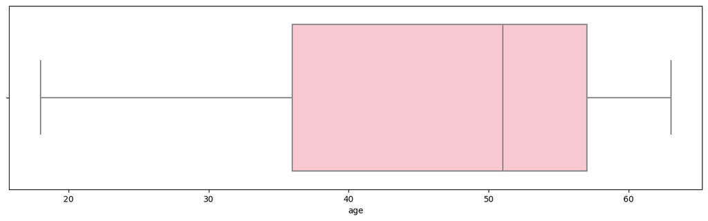

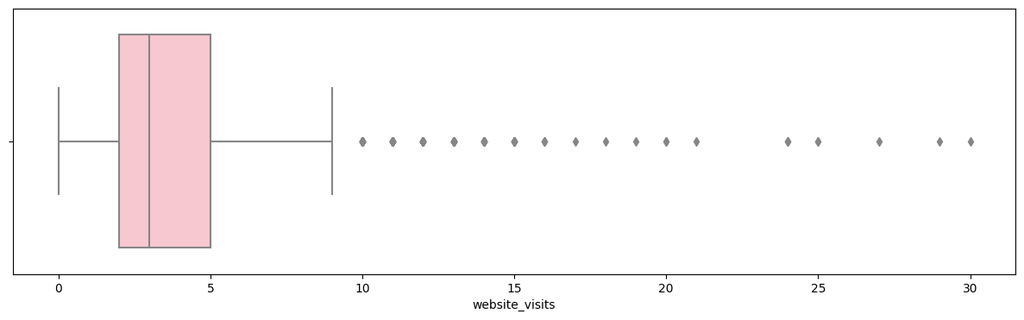

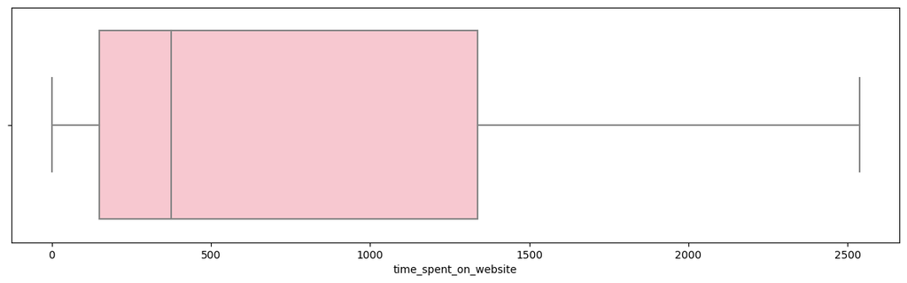

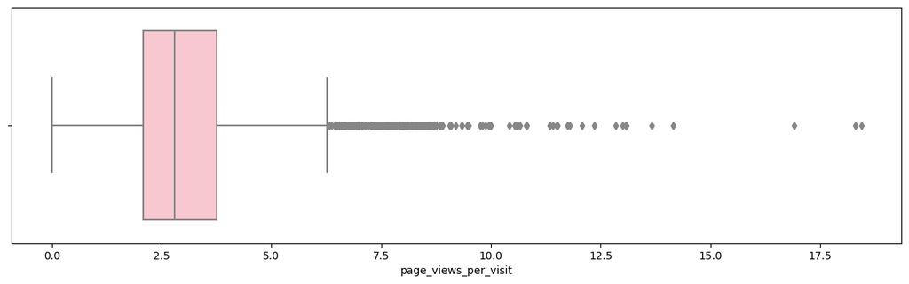

```python
num_cols = df.select_dtypes('number').columns

for i in df[num_cols[ :-1]]:
    plt.figure(figsize = (15, 4))
    sns.boxplot(x = df[i], color="pink")
    plt.show()
```

### **Univariate analysis for categorical variables**

```python
# Printing the % sub categories of each category
cat_cols = list(df.select_dtypes("object").columns)

for i in np.array(cat_cols):
    print(df[i].value_counts(normalize=True))
    print('*'*40)
```

```
current_occupation
Professional    0.567216
Unemployed      0.312446
Student         0.120338
Name: proportion, dtype: float64
first_interaction
Website       0.551171
Mobile App    0.448829
Name: proportion, dtype: float64
profile_completed
High      0.490893
Medium    0.485906
Low       0.023200
Name: proportion, dtype: float64
last_activity
Email Activity      0.493929
Phone Activity      0.267563
Website Activity    0.238508
Name: proportion, dtype: float64
print_media_type1
No     0.892238
Yes    0.107762
Name: proportion, dtype: float64
print_media_type2
No     0.94948
Yes    0.05052
Name: proportion, dtype: float64
digital_media
No     0.885733
Yes    0.114267
Name: proportion, dtype: float64
educational_channels
No     0.847138
Yes    0.152862
Name: proportion, dtype: float64
referral
No     0.979835
Yes    0.020165
Name: proportion, dtype: float64
```

#### **Observations:**

- Most of the leads are working professionals.
- As expected, the majority of the leads interacted with ExtraaLearn from the website.
- The amjority percentage of profile completions are categorized as high and medium that is 49.1% and 48.6%, respectively. Only 2.3% of the profile completions are categorized as low.
- Approx 49.4% of the leads had their last activity over email, followed by 26.8% having phone activity. This implies that the majority of the leads prefer to communicate via email.

```python
# changing the columns 8:13 into numerical types for easier use during analysis and modeling
for i in range(8, 14):
    df.iloc[ : , i] = df.iloc[ : , i].replace(["Yes", "No"], [1, 0])
    df = df.astype({df.iloc[ : , i].name : int})
#df1.iloc[ : , 8].astype(int)
df.info()
```

```
<class 'pandas.core.frame.DataFrame'>
RangeIndex: 4612 entries, 0 to 4611
Data columns (total 14 columns):
 #   Column                 Non-Null Count  Dtype
---  ------                 --------------  -----
 0   age                    4612 non-null   int64
 1   current_occupation     4612 non-null   object
 2   first_interaction      4612 non-null   object
 3   profile_completed      4612 non-null   object
 4   website_visits         4612 non-null   int64
 5   time_spent_on_website  4612 non-null   int64
 6   page_views_per_visit   4612 non-null   float64
 7   last_activity          4612 non-null   object
 8   print_media_type1      4612 non-null   int32
 9   print_media_type2      4612 non-null   int32
 10  digital_media          4612 non-null   int32
 11  educational_channels   4612 non-null   int32
 12  referral               4612 non-null   int32
 13  status                 4612 non-null   int32
dtypes: float64(1), int32(6), int64(3), object(4)
memory usage: 396.5+ KB
```

## EDA

- **Questions**
1. Leads will have different expectations from the outcome of the course and the current occupation may play a key role in getting them to participate in the program. Find out how current occupation affects lead status.
2. The company's first impression on the customer must have an impact. Do the first channels of interaction have an impact on the lead status?
3. The company uses multiple modes to interact with prospects. Which way of interaction works best?
4. The company gets leads from various channels such as print media, digital media, referrals, etc. Which of these channels have the highest lead conversion rate?
5. People browsing the website or mobile application are generally required to create a profile by sharing their personal data before they can access additional information.Does having more details about a prospect increase the chances of conversion?

#### Occupation vs status

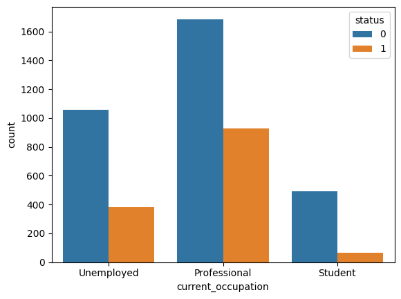

```python
sns.countplot(x = 'current_occupation', hue = 'status', data = df)
```

#### **Observations:**

- We can see that professional or unemplyed personnel leads are more likely to opt for a course offered by the organization and the students are least likely to be converted.

#### Channel vs status

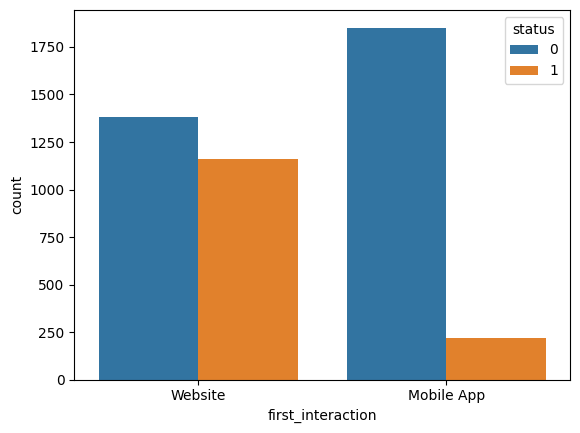

```python
sns.countplot(x = 'first_interaction', hue = 'status', data = df)
```

#### **Observations:**

- We can see that the lead who had their first interaction through the website on their PC are more likely to be converted to a customer than mobile users

#### Mode of interaction vs Status

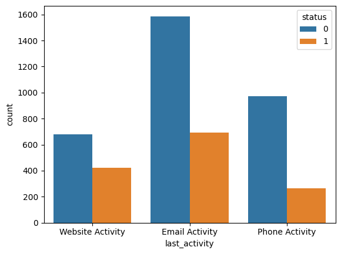

```python
sns.countplot(x = 'last_activity', hue = 'status', data = df)
```

#### Rate of Conversion vs Channels

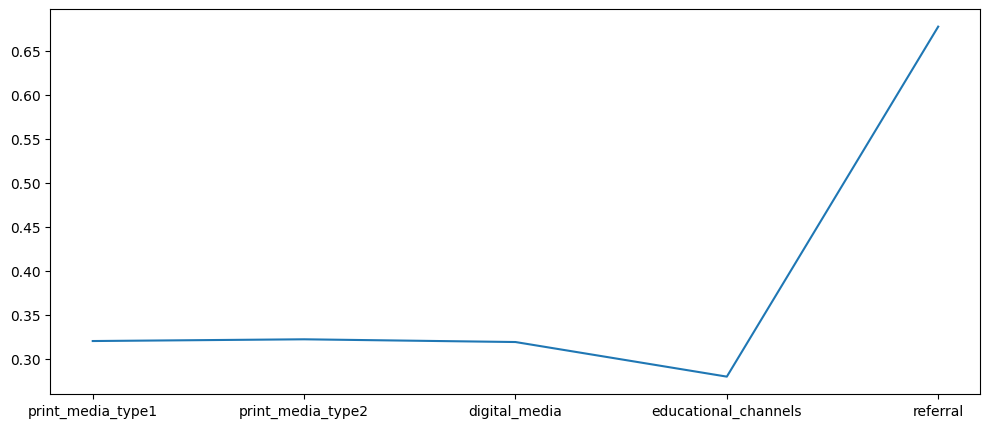

```python
arr_ad = ['print_media_type1', 'print_media_type2', 'digital_media', 'educational_channels', 'referral']
rate=[]

for i in range(8, 13):
    rate.append(df[df.iloc[ : , i] == 1][df['status'] == 1].shape[0] / df[df.iloc[ : ,i] == 1].shape[0])

plt.figure(figsize=[12,5])
sns.lineplot(x = arr_ad, y=rate)
```

#### **Observations:**

- The most successful conversion rate is through the means of refereeal, followed by print medias and digital media being almost the same, and education channels being the lowest in terms of rate of conversion

#### Profile Completion vs Status

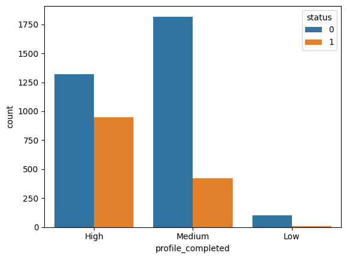

```python
sns.countplot(x = 'profile_completed',  hue = 'status', data=df)
```

#### **Observations:**

- While the amount people who complete their profile on high aren't that much more than those with medium completion, it is visible that they are the most likely to become a customer
- Almost no people who have low profile completion necame a customer

#### Let's check the relationship between different numerical variables

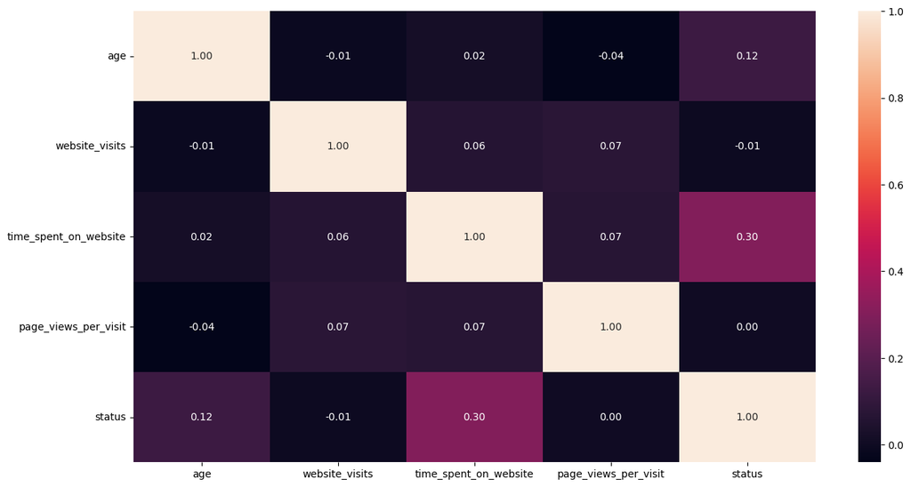

```python
plt.figure(figsize=(15,8))
sns.heatmap(df[num_cols].corr(), annot = True, fmt = '.2f')
```

#### **Observations:**

- There is a weak positive correlation between time spent on website and status. Which indicates a liklihood that the longer a lead stays on the website the better the chance of converting them to a paid customer.

### **Data preparation for modeling**

```python
#creating dummy values for categorical columns
df1 = pd.get_dummies(data = df, columns = cat_cols, drop_first = True)
df1.head()
```

|  | age | website_visits | time_spent_on_website | page_views_per_visit | status | current_occupation_Student | current_occupation_Unemployed | first_interaction_Website | profile_completed_Low | profile_completed_Medium | last_activity_Phone Activity | last_activity_Website Activity | print_media_type1_1 | print_media_type2_1 | digital_media_1 | educational_channels_1 | referral_1 |
| --- | --- | --- | --- | --- | --- | --- | --- | --- | --- | --- | --- | --- | --- | --- | --- | --- | --- |
| 0 | 57 | 7 | 1639 | 1.861 | 1 | False | True | True | False | False | False | True | True | False | True | False | False |
| 1 | 56 | 2 | 83 | 0.320 | 0 | False | False | False | False | True | False | True | False | False | False | True | False |
| 2 | 52 | 3 | 330 | 0.074 | 0 | False | False | True | False | True | False | True | False | False | True | False | False |
| 3 | 53 | 4 | 464 | 2.057 | 1 | False | True | True | False | False | False | True | False | False | False | False | False |
| 4 | 23 | 4 | 600 | 16.914 | 0 | True | False | True | False | False | False | False | False | False | False | False | False |

```python
# Separating the independant variables(X) from the dependant variable(Y)
X = df1.drop(columns = 'status')

Y = df1['status']
```

```python
#splitting data into train and test data
X_train, X_test, Y_train, Y_test = train_test_split(X, Y, test_size = 0.3, random_state = 1)
```

#### Model evaluation criterion

The model can make two types of wrong predictions:

- Predicting a lead will not become a customer when in reality they actually do
- Predicting a lead will become a customer when they actually don't

*Which case is more important?*

Predicting a lead will not become a customer when in reality they actually do, i.e., losing out on a valuable paid customer. This would be considered a major miss for any employee lead predictor and hence the more important case of wrong predictions.

Hence, the company would want the Recall to be maximized, the greater the Recall, the higher the chances of minimizing false negatives. Hence, the focus should be on increasing the Recall (minimizing the false negatives) or, in other words, identifying the true positives (i.e. Class 1) very well.

##### **Creating metric function**

```python
def metrics_score(actual, predicted):
    print(classification_report(actual, predicted))

    cm = confusion_matrix(actual, predicted)
    plt.figure(figsize=(8,5))

    sns.heatmap(cm, annot=True,  fmt='.2f', xticklabels=['Not Converted', 'Converted'], yticklabels=['Not Converted', 'Converted'])
    plt.ylabel('Actual')
    plt.xlabel('Predicted')
    plt.show()
```

## Building a Decision Tree model

### Building our decision tree

```python
dt = DecisionTreeClassifier(random_state = 1)

dt.fit(X_train, Y_train)
```

```
DecisionTreeClassifier(random_state=1)
```

```
              precision    recall  f1-score   support

           0       1.00      1.00      1.00      2273
           1       1.00      1.00      1.00       955

    accuracy                           1.00      3228
   macro avg       1.00      1.00      1.00      3228
weighted avg       1.00      1.00      1.00      3228
```

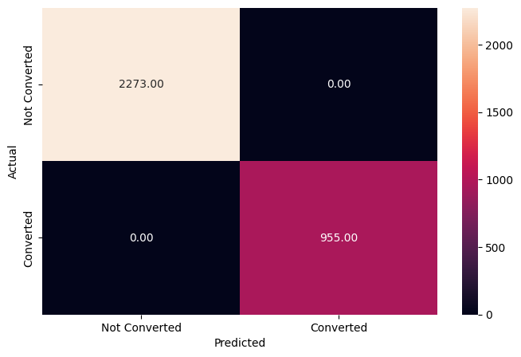

```python
# Checking performance on the training data
Y_train_p1 = dt.predict(X_train)

metrics_score(Y_train, Y_train_p1)
```

#### **Observations:**

- The Decision tree is giving a 100% score for all metrics on the training dataset.

```
              precision    recall  f1-score   support

           0       0.87      0.86      0.86       962
           1       0.69      0.70      0.70       422

    accuracy                           0.81      1384
   macro avg       0.78      0.78      0.78      1384
weighted avg       0.81      0.81      0.81      1384
```

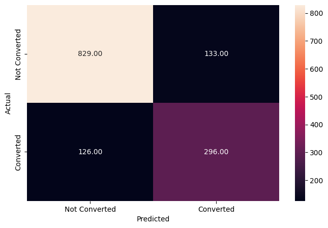

```python
# Checking performance on the test dataset
Y_test_p1 = dt.predict(X_test)

metrics_score(Y_test, Y_test_p1)
```

#### **Observations:**

- The Decision Tree works well on the training data but not so well on the test data as the recall is 0.70 in comparison to 1 for the training dataset, i.e., the Decision Tree is overfitting the training data.

## Do we need to prune the tree?

Since our tree is Overfitting the data, we need to prune it

#### Visualizing our un-pruned tree

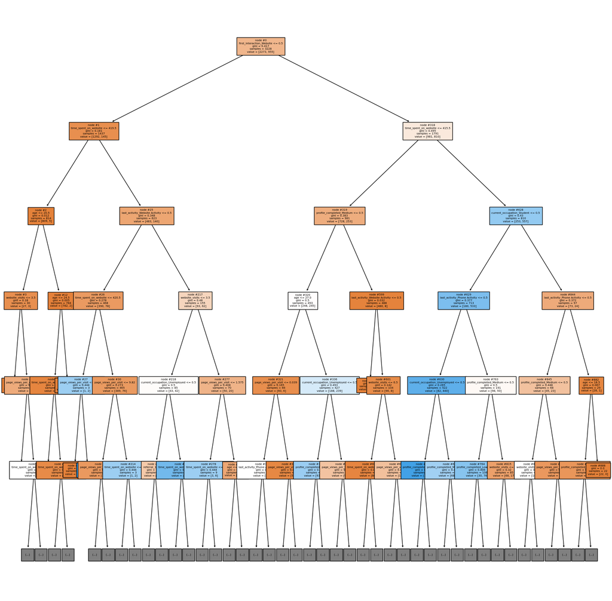

```python
features = list(X.columns)

plt.figure(figsize = (20, 20))

tree.plot_tree(dt, feature_names = features, max_depth=5, filled = True, fontsize = 5, node_ids = True)

plt.show()
```

#### To prune our obviously overfitted model, we can try to tune it by setting some limits on some of its parameters

```python
dtt = DecisionTreeClassifier(random_state = 1, class_weight = {0: 0.3, 1: 0.7})

params = {'max_depth': np.arange(2, 10),
              'criterion': ['gini', 'entropy'],
              'min_samples_leaf': [5, 10, 20, 25]
             }

scorer = metrics.make_scorer(recall_score, pos_label = 1)

grid = GridSearchCV(estimator=dtt,
                    param_grid=params,
                    scoring=scorer,
                    cv=7
                    )

grid.fit(X_train, Y_train)
```

```
GridSearchCV(cv=7,
             estimator=DecisionTreeClassifier(class_weight={0: 0.3, 1: 0.7},
                                              random_state=1),
             param_grid={'criterion': ['gini', 'entropy'],
                         'max_depth': array([2, 3, 4, 5, 6, 7, 8, 9]),
                         'min_samples_leaf': [5, 10, 20, 25]},
             scoring=make_scorer(recall_score, pos_label=1))
```

```
              precision    recall  f1-score   support

           0       0.94      0.77      0.85      2273
           1       0.62      0.88      0.73       955

    accuracy                           0.80      3228
   macro avg       0.78      0.83      0.79      3228
weighted avg       0.84      0.80      0.81      3228
```

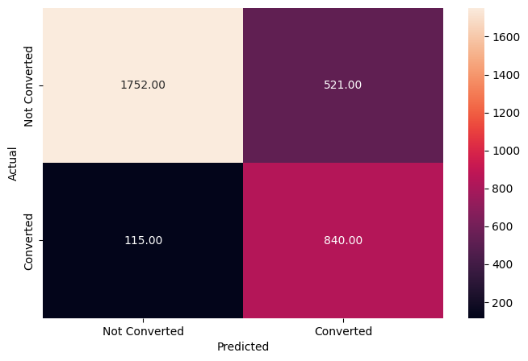

```
              precision    recall  f1-score   support

           0       0.93      0.77      0.84       962
           1       0.62      0.86      0.72       422

    accuracy                           0.80      1384
   macro avg       0.77      0.82      0.78      1384
weighted avg       0.83      0.80      0.80      1384
```

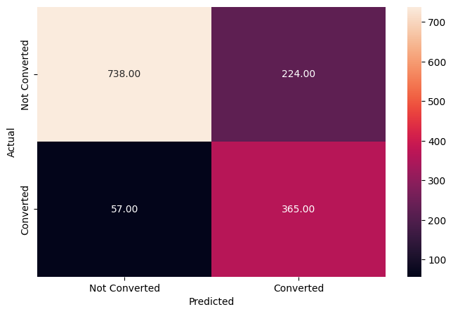

```python
model = grid.best_estimator_
model.fit(X_train, Y_train)
Y_train_p = model.predict(X_train)
Y_test_p = model.predict(X_test)

metrics_score(Y_train, Y_train_p)
metrics_score(Y_test, Y_test_p)
```

#### Visualising our tuned tree

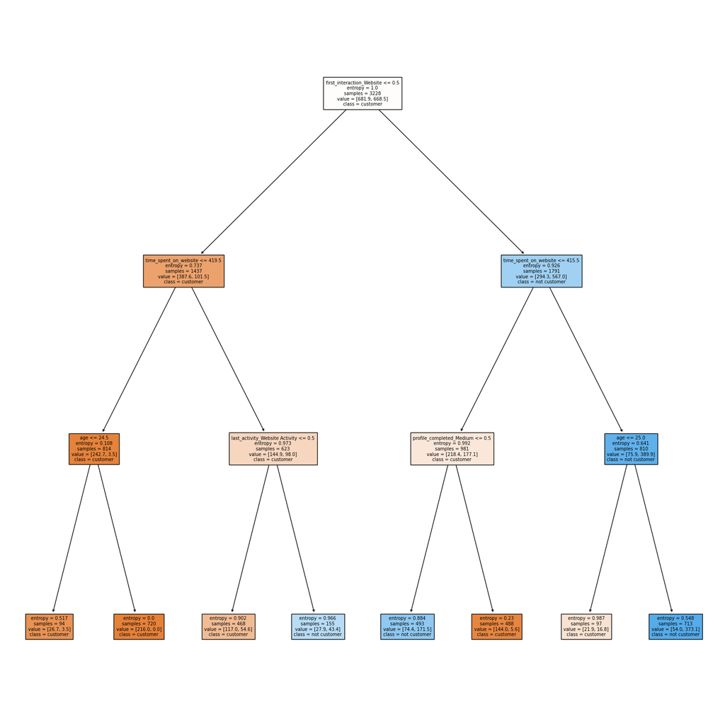

```python
plt.figure(figsize=(20,20))
classes = ['customer','not customer']
tree.plot_tree(model,feature_names=list(X.columns),class_names=classes,filled=True, fontsize=7, max_depth=5)
plt.show()
```

#### Cost complexity Pruning

```python
path = dt.cost_complexity_pruning_path(X_train, Y_train)

alphas = path.ccp_alphas
impurities = path.impurities
print(alphas)
```

```
[0.         0.00018358 0.00018775 0.0001994  0.00020007 0.00020166
 0.00020401 0.000206   0.00020653 0.00020653 0.00020653 0.00020653
 0.00022305 0.00023234 0.00023234 0.00024502 0.00024783 0.00024783
 0.00025816 0.00025816 0.00025816 0.00026553 0.00026553 0.00026553
 0.00026553 0.00026553 0.00026553 0.00026553 0.00026676 0.00027107
 0.00027537 0.00027537 0.00027561 0.00027718 0.00027881 0.00028029
 0.00028053 0.00028163 0.00028163 0.00028225 0.00028397 0.00028397
 0.00028596 0.00028766 0.00028914 0.00028914 0.00028914 0.00028914
 0.00029157 0.00029157 0.0002943  0.00029504 0.00029601 0.00029787
 0.00030164 0.00031196 0.00031351 0.00031864 0.00033044 0.00034421
 0.00034421 0.00036857 0.0003688  0.00037112 0.00037175 0.00038246
 0.00038724 0.00039179 0.00040527 0.00040833 0.00041305 0.00041305
 0.00041305 0.00041305 0.00041305 0.00041305 0.00041305 0.00041305
 0.00041305 0.00041305 0.00041305 0.00041305 0.00041305 0.00041305
 0.00041305 0.00041305 0.00041305 0.00041305 0.00041305 0.00041305
 0.00041305 0.00041305 0.00042166 0.00042166 0.00044067 0.00044256
 0.00044551 0.00045092 0.00045141 0.00045158 0.00045999 0.00046309
 0.00046468 0.00046468 0.00046468 0.00046468 0.00046468 0.00046468
 0.00046468 0.00046468 0.00047125 0.00047206 0.00047206 0.0004766
 0.00048041 0.0004823  0.00048413 0.00049337 0.00049566 0.00049799
 0.0005004  0.00050067 0.0005047  0.00050599 0.00050663 0.00050693
 0.00051632 0.00051632 0.00051632 0.00051834 0.0005218  0.00053107
 0.00053107 0.00053107 0.00053358 0.00053671 0.00053926 0.00055074
 0.00055189 0.00055762 0.00055762 0.00055781 0.00056244 0.00056411
 0.00056523 0.00056834 0.00057192 0.00057234 0.00057414 0.00058196
 0.00058745 0.00059688 0.0006008  0.00060409 0.0006346  0.00064191
 0.00064539 0.00065966 0.00066383 0.00066383 0.00068435 0.00070809
 0.00071423 0.00072223 0.00072962 0.0007588  0.00076943 0.00079768
 0.00080947 0.00082193 0.00088511 0.00092864 0.00094941 0.00095132
 0.00095592 0.00098334 0.0009861  0.00099358 0.00101657 0.00118729
 0.00120124 0.00136109 0.00150281 0.00230118 0.00262499 0.00288041
 0.00389512 0.00392771 0.00628176 0.00686323 0.00778422 0.00781155
 0.01044623 0.01098027 0.01323202 0.03509107 0.0507686  0.0609834 ]
```

```python
# For each alpha we will append our model to a list
clfs = []
for alpha in alphas:
    clf = tree.DecisionTreeClassifier(random_state=0, ccp_alpha=alpha)
    clf.fit(X_train, Y_train)
    clfs.append(clf)
```

We will remove the last element in clfs and ccp_alphas, because it is the trivial tree with only one node.

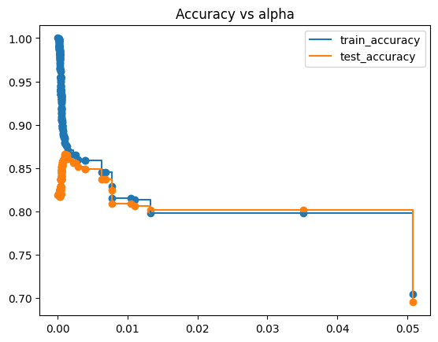

```python
clfs = clfs[:-1]
alphas = alphas[:-1]

train_acc = []
test_acc = []

#Calculating accuracy scores for each alpha in train and test data
for c in clfs:
    Y_train_p = c.predict(X_train)
    Y_test_p = c.predict(X_test)
    train_acc.append(accuracy_score(Y_train_p,Y_train))
    test_acc.append(accuracy_score(Y_test_p,Y_test))

#Plotting accuracy vs alpha

plt.scatter(alphas,train_acc)
plt.scatter(alphas,test_acc)

plt.plot(alphas,train_acc,label='train_accuracy',drawstyle="steps-post")
plt.plot(alphas,test_acc,label='test_accuracy',drawstyle="steps-post")
plt.legend()
plt.title('Accuracy vs alpha')
plt.show()
```

```
              precision    recall  f1-score   support

           0       0.96      0.81      0.88      2706
           1       0.46      0.84      0.60       522

    accuracy                           0.82      3228
   macro avg       0.71      0.83      0.74      3228
weighted avg       0.88      0.82      0.83      3228
```

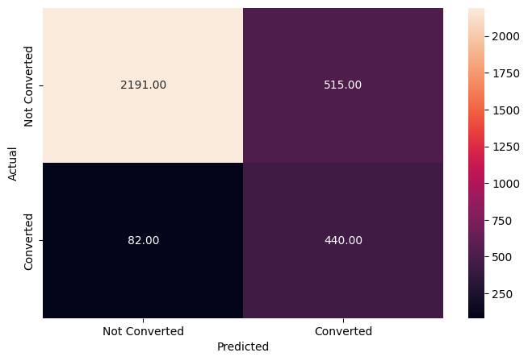

```
              precision    recall  f1-score   support

           0       0.96      0.80      0.88      1150
           1       0.46      0.84      0.60       234

    accuracy                           0.81      1384
   macro avg       0.71      0.82      0.74      1384
weighted avg       0.88      0.81      0.83      1384
```

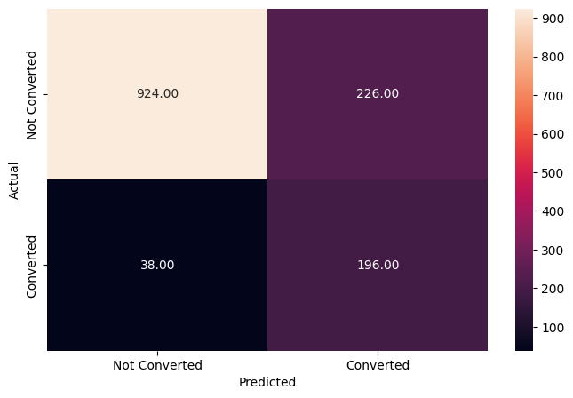

```python
clf_ = tree.DecisionTreeClassifier(random_state=1, ccp_alpha=0.01)
clf_.fit(X_train,Y_train)

Y_train_p = clf_.predict(X_train)
Y_test_p = clf_.predict(X_test)

metrics_score(Y_train_p, Y_train)
metrics_score(Y_test_p, Y_test)
```

#### Visualising our tuned tree

[output not shown]

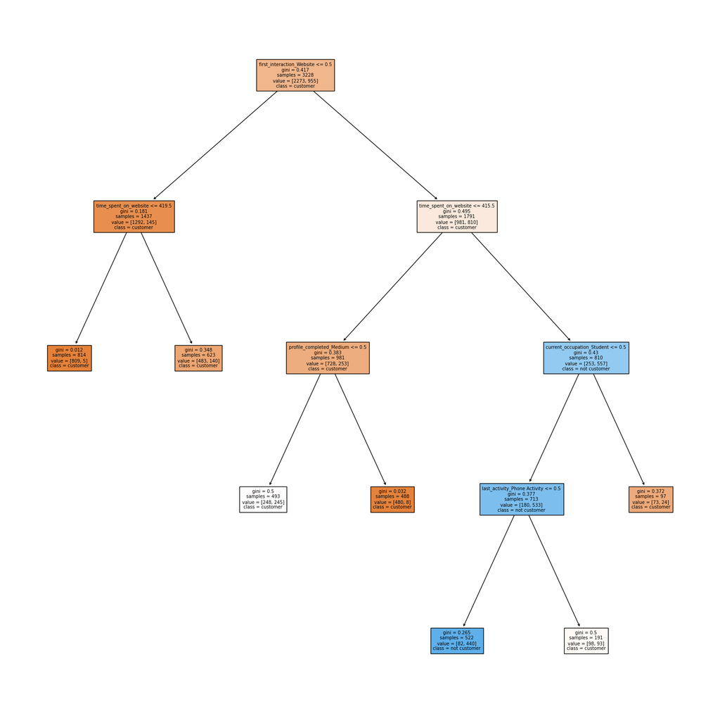

```python
plt.figure(figsize=(20,20))
classes = ['customer','not customer']
tree.plot_tree(clf_, feature_names=list(X.columns), class_names=classes, filled=True, fontsize=7)
```

#### Feature importances

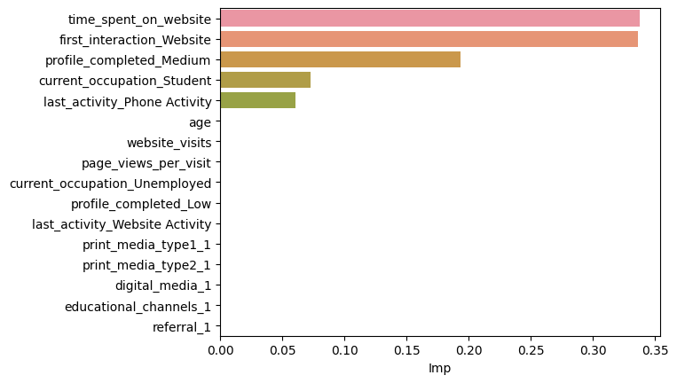

```python
imp = pd.DataFrame(clf_.feature_importances_, columns = ["Imp"], index = X_train.columns).sort_values(by = 'Imp', ascending = False)
sns.barplot(x= imp.Imp, y= imp.index)
```

#### **Observations:**

- Time spent on the website and first_interaction_website are the most important features followed by profile_completed, current occupation, and last_activity.

## Building a Random Forest model

```python
# Fitting the random forest tree classifier on the training data
rf =  RandomForestClassifier(random_state = 1, criterion='entropy')
rf.fit(X_train, Y_train)
```

```
RandomForestClassifier(criterion='entropy', random_state=1)
```

```
              precision    recall  f1-score   support

           0       1.00      1.00      1.00      2273
           1       1.00      1.00      1.00       955

    accuracy                           1.00      3228
   macro avg       1.00      1.00      1.00      3228
weighted avg       1.00      1.00      1.00      3228
```

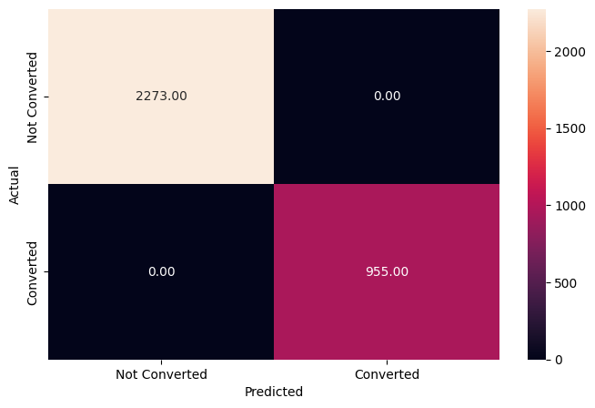

```
              precision    recall  f1-score   support

           0       0.87      0.92      0.90       962
           1       0.80      0.69      0.74       422

    accuracy                           0.85      1384
   macro avg       0.84      0.81      0.82      1384
weighted avg       0.85      0.85      0.85      1384
```

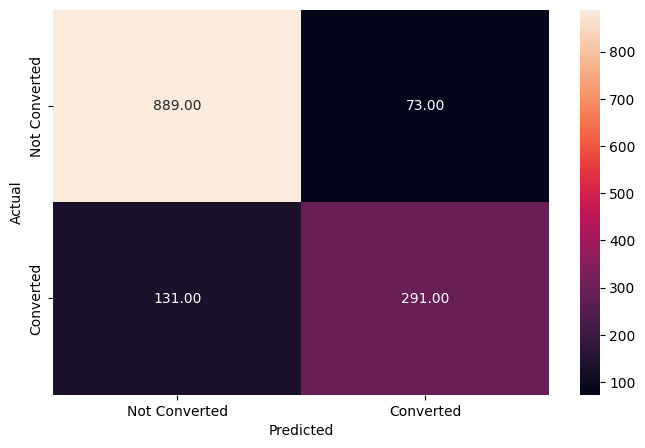

```python
Y_train_p2 = rf.predict(X_train)

Y_test_p2 = rf.predict(X_test)

metrics_score(Y_train, Y_train_p2)
metrics_score(Y_test, Y_test_p2)
```

#### Feature importances

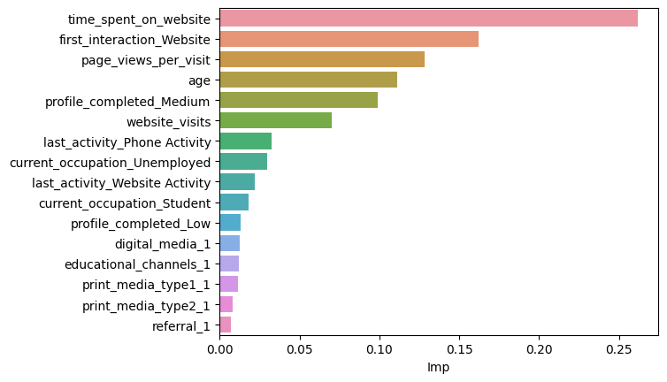

```python
imp = pd.DataFrame(rf.feature_importances_, columns = ["Imp"], index = X_train.columns).sort_values(by = 'Imp', ascending = False)
sns.barplot(x= imp.Imp, y= imp.index)
```

#### **Observations**

- Time spent on the website and first_interaction_website are the most important features followed by page views per visit, age, profile completion and website visits, with some importance given to other features as well.

## Do we need to prune the tree?

**Unlike decision trees, random forest models do not need pruning**

- Pruning trees in a random forest is not recommended because it can negatively impact the overall performance of the model.

## Actionable Insights and Recommendations

- The time spent on the website can play a key role in identifying if a lead will be converted or not.
- The company should spend time and money developing their website to attract and keep the attention of leads.
- Leads that filled out the profile had a higher chance of converting.
- Encouraging leads to fill out the profile with a discount might improve the number of profiles completed.
- The older a lead was the more likely they were to convert.
- Professionals and unemployed personnel make up the majority of converted leads
- People who used the website through their phones are much less likely to convert

### Project insights

- Our goal is to maximize the Recall value. The greater the Recall score, higher the chances of minimizing False Negatives which are ultimately more beneficial than predicting false positives for the company
- The tree models we have constructed can be used to help the company predict future leads which may be converted
- This in turn will help them to focus their marketing towards the audiences which are the most likely to become customerss
- Ftom feature importances, we can see that the time_spent_on_website, age, profile_completion, first interaction, and profession, are the major factors of the model.